# PM 566 Midterm

# **STDs by Disease, County, Year and Sex**

#### 10-22-2023

Importing libraries:

```r
library(data.table)
library(dplyr)
library(ggplot2)
```

## Introduction

This data comprises statistics on the number of cases and infection rates of sexually transmitted diseases (specifically chlamydia, gonorrhea, and early syphilis, encompassing primary, secondary, and early latent syphilis) that have been reported for California residents. The data is categorized by disease type, county, year, and gender.

The data was collected for cases with estimated diagnosis dates spanning from 2001 up to the most recent year available. It was sourced from California Confidential Morbidity Reports and Laboratory Reports, all of which were submitted to the California Department of Public Health (CDPH) by July of the current year. These reports adhered to the surveillance case definition for each respective disease.

After looking at the data, the main question of interest we wanted to investigate was : Which STD has the highest prevalence in California, and how is this disease geographically spread across the state? Further analysis was conducted to look at the year that had the highest STD rates and the different between infection rates based off of sex.

## Methods

### 1. Retrieving the Data

STD data was retrieved from [“https://data.chhs.ca.gov/dataset/stds-in-california-by-disease-county-year-and-sex”.](https://data.chhs.ca.gov/dataset/stds-in-california-by-disease-county-year-and-sex)

```r
std <- data.table::fread("std.csv")
```

While looking at the data, we noticed that there weren’t any latitude and longitude coordinates present that were necessary to conduct a geopraphical analysis. Thus, the geographical data was retrieved from "https://public.opendatasoft.com/explore/dataset/us-county-boundaries/export/?disjunctive.statefp&disjunctive.countyfp&disjunctive.name&disjunctive.namelsad&disjunctive.stusab&disjunctive.state_name&refine.stusab=CA". and then merged with the original data set.

```r
CA <- data.table::fread("us-county-boundaries.csv")
CA <- CA[,.(NAME, INTPTLAT, INTPTLON)]
```

### 2. Data cleaning and wrangling

Merging both data sets:

```r
std <- merge(
  x = std,
  y = CA,
  by.x = "County",
  by.y = "NAME",
  all.x = TRUE,
  all.y = FALSE,
  allow.cartesian = TRUE
)
```

Removing NAs:

```r
std <- filter(std, !is.na(Cases))
std$Rate[which(std$Rate == "-")] <- NA
std$Rate[which(std$Rate == "-")] <- NA
std <- filter(std, !is.na(Rate))
```

Changing “Rate” format from character to numeric:

```r
std[ , Rate := gsub("\\*", "", Rate)]
std[ , Rate := as.numeric(Rate)]
```

Removing rows in the “county” column that are named “California.” Then, creating a new “California” variable.

```r
Cali <- std[County == "California"]
std <- std[County != "California"]
```

## Preliminary Data

### Summary Table

```r
table_sex <- Cali[ , .(
  NumofDiseases = length(Cases),
  Cases_avg = round(mean(Cases, na.rm = TRUE)),
  Cases_sd = sd(Cases, na.rm = TRUE),
  Rate_avg = mean(Rate, na.rm = TRUE),
  Rate_sd = sd(Rate, na.rm = TRUE)
  ), by = .(Year, Sex)]
knitr::kable(table_sex, col.names = c("Year", "Sex", "Count of Diseases", "Cases Avg", "Cases SD", "Rate Avg", "Rate SD"))
```

| Year | Sex | Count of Diseases | Cases Avg | Cases SD | Rate Avg | Rate SD |
| --- | --- | --- | --- | --- | --- | --- |
| 2001 | Female | 3 | 28844 | 41110.26 | 166.36667 | 237.10256 |
| 2001 | Male | 3 | 12791 | 12039.87 | 74.50000 | 70.10193 |
| 2001 | Total | 3 | 41944 | 52847.99 | 121.56667 | 153.13407 |
| 2002 | Female | 3 | 30868 | 44249.78 | 175.83333 | 252.04256 |
| 2002 | Male | 3 | 14604 | 13451.54 | 84.03333 | 77.40390 |
| 2002 | Total | 3 | 45743 | 57455.33 | 130.90000 | 164.46115 |
| 2003 | Female | 3 | 32366 | 46081.94 | 181.96667 | 259.13036 |
| 2003 | Male | 3 | 15597 | 14607.35 | 88.60000 | 82.95330 |
| 2003 | Total | 3 | 48067 | 60327.61 | 135.83333 | 170.48444 |
| 2004 | Female | 3 | 34463 | 48094.33 | 191.80000 | 267.70022 |
| 2004 | Male | 3 | 17449 | 15802.51 | 98.10000 | 88.84329 |
| 2004 | Total | 3 | 52057 | 63409.59 | 145.63333 | 177.37061 |
| 2005 | Female | 3 | 36121 | 49313.19 | 199.70000 | 272.60435 |
| 2005 | Male | 3 | 18986 | 16880.86 | 106.06667 | 94.31905 |
| 2005 | Total | 3 | 55352 | 65824.54 | 153.83333 | 182.93885 |
| 2006 | Female | 3 | 37927 | 52367.21 | 208.13333 | 287.41702 |
| 2006 | Male | 3 | 19636 | 17662.97 | 108.93333 | 98.00573 |
| 2006 | Total | 3 | 57842 | 69800.70 | 159.56667 | 192.55101 |
| 2007 | Female | 3 | 38905 | 55006.27 | 211.76667 | 299.39459 |
| 2007 | Male | 3 | 20132 | 18946.50 | 110.76667 | 104.23657 |
| 2007 | Total | 3 | 59252 | 73844.18 | 162.10000 | 202.06019 |
| 2008 | Female | 3 | 38775 | 57240.62 | 209.33333 | 308.97620 |
| 2008 | Male | 3 | 20524 | 21116.05 | 111.96667 | 115.16550 |
| 2008 | Total | 3 | 59523 | 78460.49 | 161.53333 | 212.88817 |
| 2009 | Female | 3 | 37368 | 56184.72 | 200.56667 | 301.55877 |
| 2009 | Male | 3 | 20881 | 21624.72 | 113.20000 | 117.26291 |
| 2009 | Total | 3 | 58451 | 77871.67 | 157.66667 | 210.00991 |
| 2010 | Female | 3 | 39123 | 58485.69 | 208.30000 | 311.38964 |
| 2010 | Male | 3 | 22656 | 23108.14 | 121.93333 | 124.32990 |
| 2010 | Total | 3 | 62018 | 81629.34 | 165.96667 | 218.44346 |
| 2011 | Female | 3 | 41396 | 62336.84 | 218.56667 | 329.17718 |
| 2011 | Male | 3 | 23917 | 24238.04 | 127.46667 | 129.13173 |
| 2011 | Total | 3 | 65509 | 86568.94 | 173.73333 | 229.59082 |
| 2012 | Female | 3 | 42963 | 63126.24 | 224.83333 | 330.33084 |
| 2012 | Male | 3 | 26461 | 24785.36 | 139.66667 | 130.83273 |
| 2012 | Total | 3 | 69561 | 87651.10 | 182.80000 | 230.34715 |
| 2013 | Female | 3 | 42493 | 61236.09 | 220.80000 | 318.22305 |
| 2013 | Male | 3 | 28291 | 24720.36 | 148.10000 | 129.42523 |
| 2013 | Total | 3 | 70880 | 85474.69 | 184.90000 | 222.92422 |
| 2014 | Female | 3 | 43508 | 61524.78 | 224.46667 | 317.43203 |
| 2014 | Male | 3 | 31852 | 26810.47 | 165.33333 | 139.20206 |
| 2014 | Total | 3 | 75474 | 87593.33 | 195.30000 | 226.64997 |
| 2015 | Female | 3 | 47038 | 65282.62 | 241.10000 | 334.60704 |
| 2015 | Male | 3 | 37263 | 29645.73 | 192.06667 | 152.76784 |
| 2015 | Total | 3 | 84435 | 93888.92 | 217.00000 | 241.29758 |
| 2016 | Female | 3 | 48776 | 65825.26 | 248.73333 | 335.61897 |
| 2016 | Male | 3 | 42253 | 31958.22 | 216.46667 | 163.76515 |
| 2016 | Total | 3 | 91342 | 96335.92 | 233.43333 | 246.18985 |
| 2017 | Female | 3 | 53863 | 71320.95 | 273.33333 | 361.91430 |
| 2017 | Male | 3 | 48562 | 35759.58 | 247.46667 | 182.20319 |
| 2017 | Total | 3 | 102643 | 105316.87 | 260.96667 | 267.78516 |
| 2018 | Female | 3 | 57215 | 74913.26 | 289.36667 | 378.84868 |
| 2018 | Male | 3 | 51592 | 38244.01 | 261.83333 | 194.10565 |
| 2018 | Total | 3 | 109081 | 111573.22 | 276.33333 | 282.63286 |
| 2019 | Female | 3 | 58149 | 75295.94 | 293.70000 | 380.32811 |
| 2019 | Male | 3 | 53140 | 39700.64 | 269.33333 | 201.20331 |
| 2019 | Total | 3 | 111531 | 113640.05 | 282.13333 | 287.51773 |
| 2020 | Female | 3 | 46510 | 55128.15 | 234.76667 | 278.32101 |
| 2020 | Male | 3 | 43287 | 28498.95 | 219.40000 | 144.41731 |
| 2020 | Total | 3 | 90065 | 81740.81 | 227.76667 | 206.69713 |

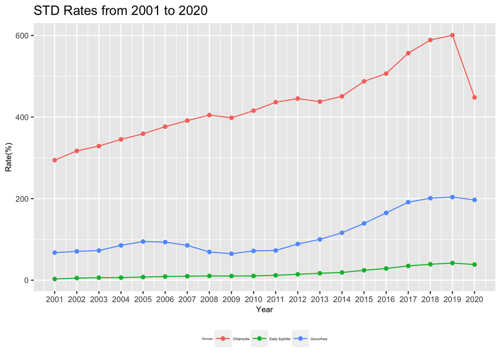

```r
ggplot(data = Cali[Sex == "Total"], mapping = aes(x = Year, y = Rate, colour = Disease)) + geom_line() + geom_point() +
  theme(legend.position = "bottom", legend.text = element_text(size = 3.5), legend.title = element_text(size = 3),
        axis.text = element_text(size = 8), axis.title = element_text(size = 8)) +
  scale_x_continuous(breaks = seq(2001, 2020, 1)) +
  labs(y = "Rate(%)", title = "STD Rates from 2001 to 2020")
```

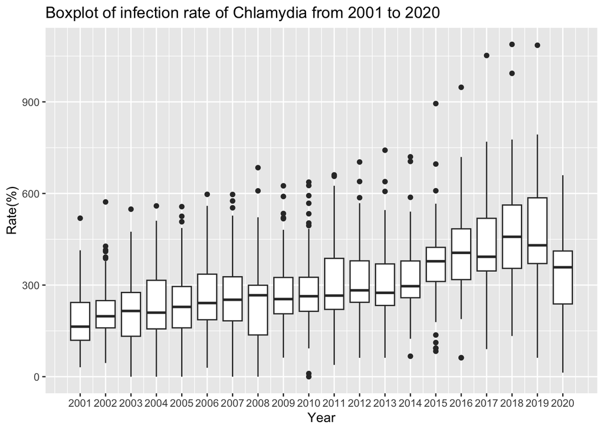

```r
ggplot() +
  geom_boxplot(data = std[Sex == "Total" & Disease == "Chlamydia"], mapping = aes(y = Rate, x = Year, group = Year)) +
  scale_x_continuous(breaks = seq(2001, 2020, 1)) +
  labs(y = "Rate(%)", title = "Boxplot of infection rate of Chlamydia from 2001 to 2020")
```

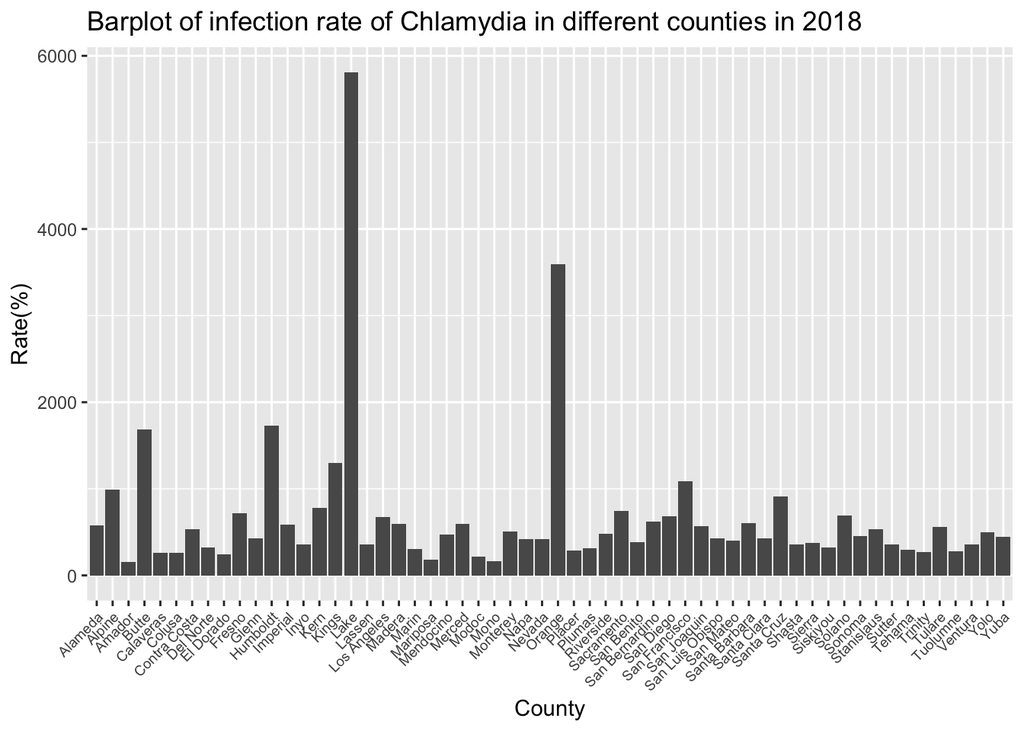

```r
ggplot() +
  geom_bar(data = std[Sex == "Total" & Disease == "Chlamydia" & Year == 2018], mapping = aes(x = County, y = Rate), stat = "identity") +
  theme(axis.text.x = element_text(angle = 45, hjust = 1, size = 7)) +
  labs(y = "Rate(%)", title = "Barplot of infection rate of Chlamydia in different counties in 2018")
```

In order to assess geographical variations in infection rates, we designed a map for a visual analysis. Our observation from this map indicates that the central valley of California, along with a selection of counties in the Bay area, exhibited the highest infection rates. Notably, the counties in closer proximity to Nevada demonstrated the lowest infection rates.

```r
library(leaflet)
Lake_2019 <- std[Sex == "Total" & Disease == "Chlamydia" & Year == 2019]
Lake_2019_pal <- colorNumeric(c('pink','lightblue','purple'), domain = Lake_2019$Rate)

leaflet(Lake_2019) %>%
  addProviderTiles('CartoDB.Positron') %>%
  addCircles(
    lat = ~INTPTLAT, lng = ~ INTPTLON,
    label = ~paste0(Rate), color = ~ Lake_2019_pal(Rate),
    opacity = 1, fillOpacity = 1, radius = 500
    ) %>%
  addLegend('bottomleft', pal = Lake_2019_pal, values = Lake_2019$Rate,
          title = 'Infection Rate (%)', opacity = 1) %>%
  addControl("Leaflet map of the infection rate of Chlamydia in 2019", position = "topright")
```

[interactive chart not shown]

A table was created to look at the differences in infection rates based off of sex. We can see that females are twice as likely to get infected when compared to males.

```r
# Filter the data
Lake_County_2018 <- std[Disease == "Chlamydia" & County == "Lake" & Year == 2018]

# Aggregate data by sex
Aggregated_Lake_County_2018 <- Lake_County_2018[, .(Cases = sum(Cases), Population = sum(Population)), by = Sex]

# Calculate the Rate
Aggregated_Lake_County_2018[, Rate := (Cases / Population) * 100, by = Sex]

# Display the aggregated data
knitr::kable(Aggregated_Lake_County_2018)
```

| Sex | Cases | Population | Rate |
| --- | --- | --- | --- |
| Female | 2664 | 408960 | 0.6514085 |
| Male | 1296 | 411336 | 0.3150709 |
| Total | 3972 | 820296 | 0.4842155 |

## Conclusion

An apparent geographic pattern emerged, with the central valley reporting the highest infection rates and a gradual decrease towards the Nevada border.

Additionally, a notable gender discrepancy was observed in Lake County in 2018, where females reported twice as many infections as males, highlighting the importance of tailored interventions and awareness initiatives.